# Tugas Pertemuan 5

Azizah

2023-09-26

```r
library(ggplot2)
library(tsibble)
library(tseries)
library(MASS)
```

### Input data

Data yang akan digunakan adalah data harga daging sapi dari Desember 2020 - Agustus 2023. Langkah pertama adalah memasukkan data yang akan digunakan

```r
library(rio)
datam5<-import("https://raw.githubusercontent.com/azizahaa/MPDW-Prak/main/P1/Data%20Harga%20Daging%20Sapi.csv")
datam5.ts<-ts(datam5[2])
```

### Plot *Time Series*

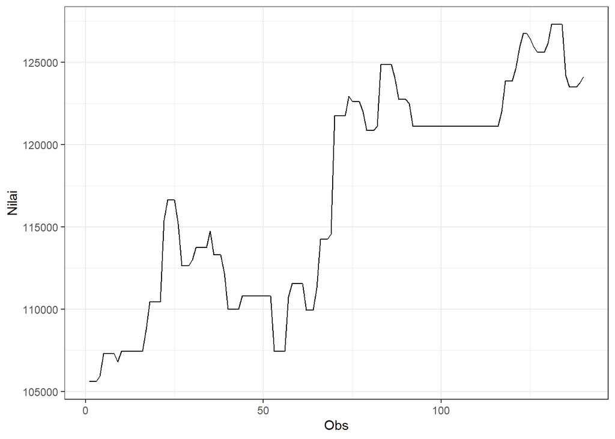

```r
plot_m5.ts <- datam5.ts |> as_tsibble() |>
  ggplot(aes(x = index, y = value)) + geom_line() + theme_bw() +
  xlab("Obs") + ylab("Nilai")
plot_m5.ts
```

```r
mean(datam5.ts)
```

```
## [1] 116907.1
```

Berdasarkan plot time series tersebut, terlihat bahwa data tidak stationer dalam rataan, ditandai dengan adanya trend pada data, dan tidak stationer dalam ragam, ditandai dengan adanya perbedaaan lebar pita pada plot.

### Plot ACF

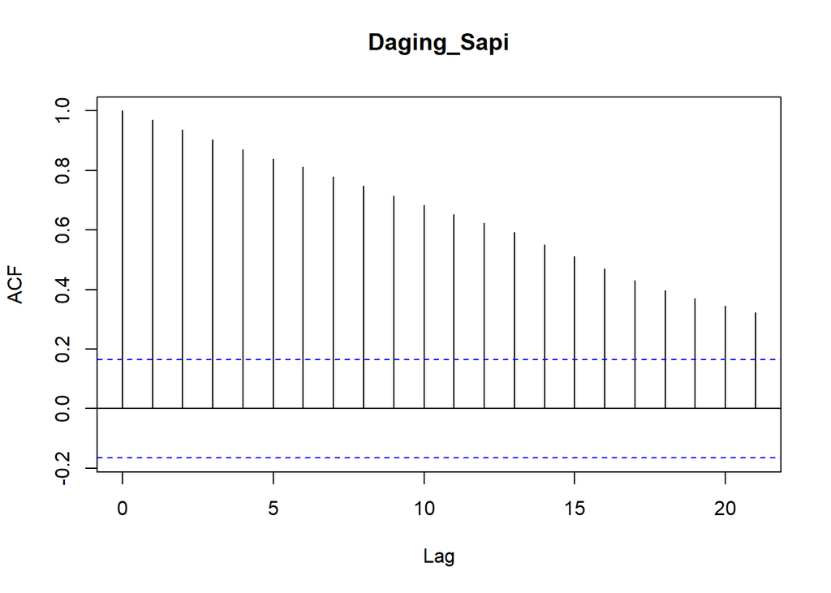

```r
acf(datam5.ts)
```

Berdasarkan plot ACF, terlihat bahwa plot ACF pada data tersebut menurun secara perlahan (*tails off slowly*) yang menandakan data tidak stasioner dalam rataan

### Uji ADF

```r
adf.test(datam5.ts)
```

```
##
##  Augmented Dickey-Fuller Test
##
## data:  datam5.ts
## Dickey-Fuller = -2.241, Lag order = 5, p-value = 0.4761
## alternative hypothesis: stationary
```

$H_0$ : Data tidak stasioner dalam rataan

$H_1$ : Data stasioner dalam rataan

Berdasarkan uji ADF tersebut, didapat *p-value* sebesar 0.4761 yang lebih besar dari taraf nyata 5% dan menandakan bahwa data tidak stasioner dalam rataan. Hal ini sesuai dengan hasil eksplorasi menggunakan plot time series dan plot ACF.

###Plot Box-cox

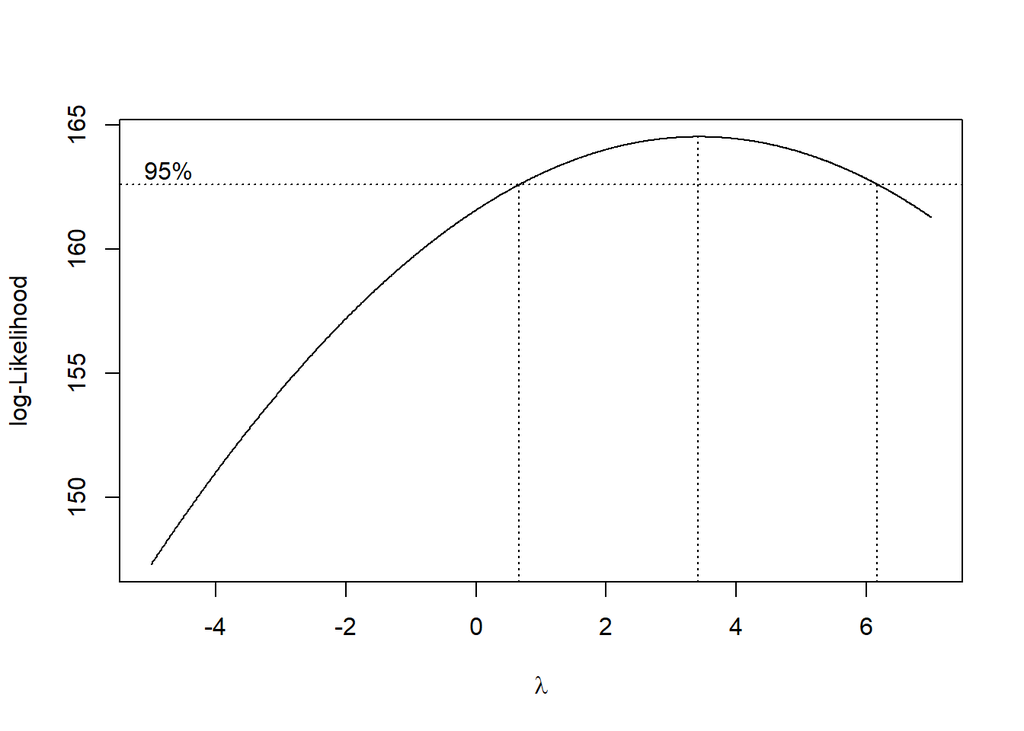

```r
index <- seq(1:length(datam5.ts))
bc = boxcox(datam5.ts~index, lambda = seq(-5,7,by=0.01))
```

```r
#Nilai Rounded Lambda
lambda <- bc$x[which.max(bc$y)]
lambda
```

```
## [1] 3.42
```

```r
#SK
bc$x[bc$y > max(bc$y) - 1/2 * qchisq(.95,1)]
```

```
##   [1] 0.67 0.68 0.69 0.70 0.71 0.72 0.73 0.74 0.75 0.76 0.77 0.78 0.79 0.80 0.81
##  [16] 0.82 0.83 0.84 0.85 0.86 0.87 0.88 0.89 0.90 0.91 0.92 0.93 0.94 0.95 0.96
##  [31] 0.97 0.98 0.99 1.00 1.01 1.02 1.03 1.04 1.05 1.06 1.07 1.08 1.09 1.10 1.11
##  [46] 1.12 1.13 1.14 1.15 1.16 1.17 1.18 1.19 1.20 1.21 1.22 1.23 1.24 1.25 1.26
##  [61] 1.27 1.28 1.29 1.30 1.31 1.32 1.33 1.34 1.35 1.36 1.37 1.38 1.39 1.40 1.41
##  [76] 1.42 1.43 1.44 1.45 1.46 1.47 1.48 1.49 1.50 1.51 1.52 1.53 1.54 1.55 1.56
##  [91] 1.57 1.58 1.59 1.60 1.61 1.62 1.63 1.64 1.65 1.66 1.67 1.68 1.69 1.70 1.71
## [106] 1.72 1.73 1.74 1.75 1.76 1.77 1.78 1.79 1.80 1.81 1.82 1.83 1.84 1.85 1.86
## [121] 1.87 1.88 1.89 1.90 1.91 1.92 1.93 1.94 1.95 1.96 1.97 1.98 1.99 2.00 2.01
## [136] 2.02 2.03 2.04 2.05 2.06 2.07 2.08 2.09 2.10 2.11 2.12 2.13 2.14 2.15 2.16
## [151] 2.17 2.18 2.19 2.20 2.21 2.22 2.23 2.24 2.25 2.26 2.27 2.28 2.29 2.30 2.31
## [166] 2.32 2.33 2.34 2.35 2.36 2.37 2.38 2.39 2.40 2.41 2.42 2.43 2.44 2.45 2.46
## [181] 2.47 2.48 2.49 2.50 2.51 2.52 2.53 2.54 2.55 2.56 2.57 2.58 2.59 2.60 2.61
## [196] 2.62 2.63 2.64 2.65 2.66 2.67 2.68 2.69 2.70 2.71 2.72 2.73 2.74 2.75 2.76
## [211] 2.77 2.78 2.79 2.80 2.81 2.82 2.83 2.84 2.85 2.86 2.87 2.88 2.89 2.90 2.91
```

[output cut: 22 more lines]

Gambar di atas menunjukkan nilai *rounded value* ($\lambda$) optimum sebesar **3.42** dan pada selang kepercayaan 95% nilai memiliki batas bawah **0,67** dan batas atas **6.17**. Selang tersebut memuat nilai satu sehingga dapat dikatakan bahwa data stasioner dalam ragam.

### Bagian 1

```r
datam5.ts1 <- datam5.ts[1:50] |> ts()
mean(datam5.ts1)
```

```
## [1] 110608
```

```r
var(datam5.ts1)
```

```
## [1] 9857690
```

#### Plot Time Series

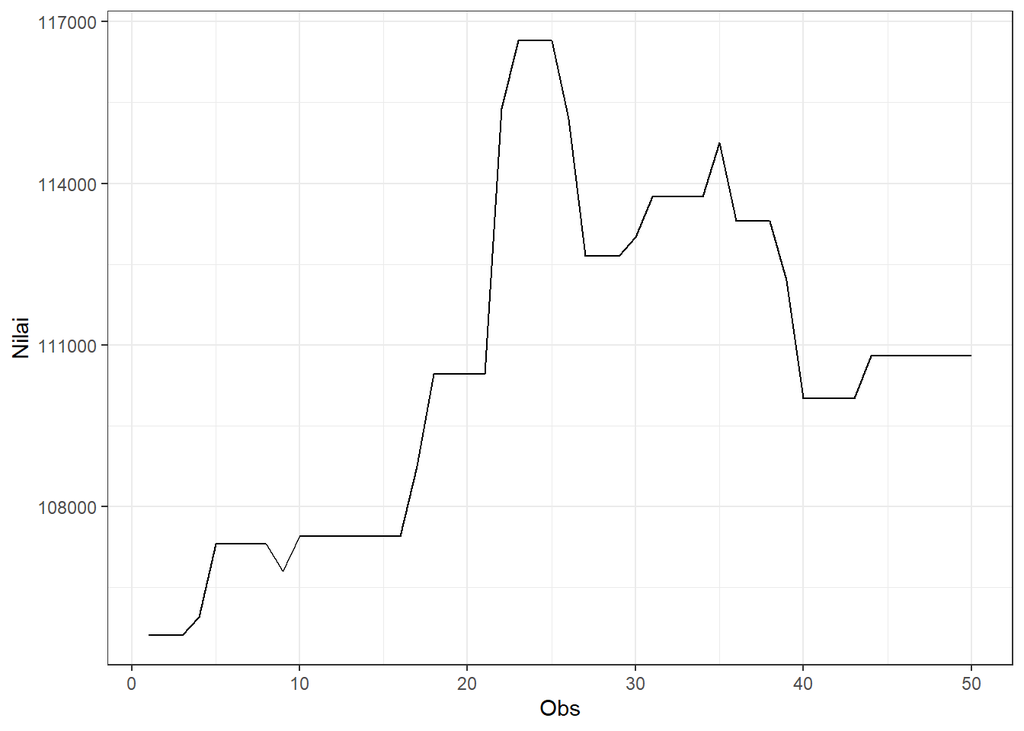

```r
datam5.ts1 |> as_tsibble() |>
  ggplot(aes(x = index, y = value)) +
  geom_line() + theme_bw() +
  xlab("Obs") + ylab("Nilai")
```

Berdasarkan plot time series tersebut, terlihat bahwa data tidak stasioner dalam rataan karena masih terdapat tren pada data, dan tidak stasioner dalam ragam karena memiliki lebar pita yang berbeda

#### Plot ACF

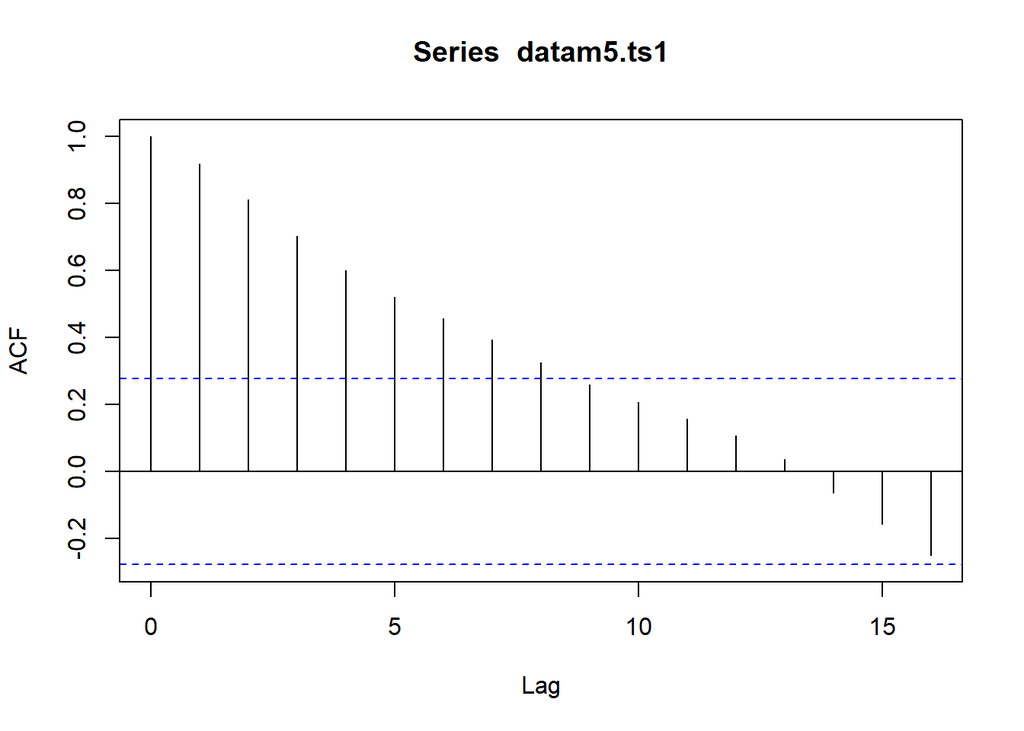

```r
acf(datam5.ts1)
```

Berdasarkan plot ACF, terlihat bahwa plot ACF pada data tersebut menurun secara perlahan (*tails off slowly*) yang menandakan data tidak stasioner dalam rataan

#### Uji ADF

```r
adf.test(datam5.ts1)
```

```
##
##  Augmented Dickey-Fuller Test
##
## data:  datam5.ts1
## Dickey-Fuller = -1.6093, Lag order = 3, p-value = 0.731
## alternative hypothesis: stationary
```

$H_0$ : Data tidak stasioner dalam rataan

$H_1$ : Data stasioner dalam rataan

Berdasarkan uji ADF tersebut, didapat *p-value* sebesar 0.731 yang lebih besar dari taraf nyata 5% dan menandakan bahwa data tidak stasioner dalam rataan. Hal ini sesuai dengan hasil eksplorasi menggunakan plot time series dan plot ACF

#### Plot Boxcox

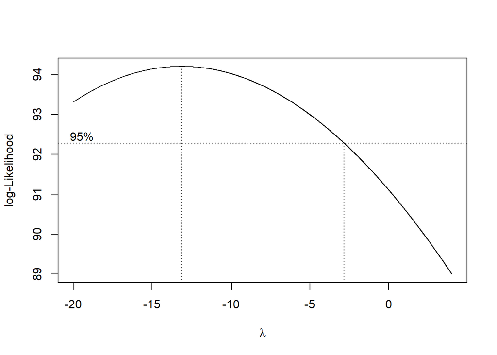

```r
index <- seq(1:50)
bc = boxcox(datam5.ts1~index, lambda = seq(-20,4,by=0.01))
```

```r
#Nilai Rounded Lambda
lambda <- bc$x[which.max(bc$y)]
lambda
```

```
## [1] -13.13
```

```r
#SK
bc$x[bc$y > max(bc$y) - 1/2 * qchisq(.95,1)]
```

```
##    [1] -20.00 -19.99 -19.98 -19.97 -19.96 -19.95 -19.94 -19.93 -19.92 -19.91
##   [11] -19.90 -19.89 -19.88 -19.87 -19.86 -19.85 -19.84 -19.83 -19.82 -19.81
##   [21] -19.80 -19.79 -19.78 -19.77 -19.76 -19.75 -19.74 -19.73 -19.72 -19.71
##   [31] -19.70 -19.69 -19.68 -19.67 -19.66 -19.65 -19.64 -19.63 -19.62 -19.61
##   [41] -19.60 -19.59 -19.58 -19.57 -19.56 -19.55 -19.54 -19.53 -19.52 -19.51
##   [51] -19.50 -19.49 -19.48 -19.47 -19.46 -19.45 -19.44 -19.43 -19.42 -19.41
##   [61] -19.40 -19.39 -19.38 -19.37 -19.36 -19.35 -19.34 -19.33 -19.32 -19.31
##   [71] -19.30 -19.29 -19.28 -19.27 -19.26 -19.25 -19.24 -19.23 -19.22 -19.21
##   [81] -19.20 -19.19 -19.18 -19.17 -19.16 -19.15 -19.14 -19.13 -19.12 -19.11
##   [91] -19.10 -19.09 -19.08 -19.07 -19.06 -19.05 -19.04 -19.03 -19.02 -19.01
##  [101] -19.00 -18.99 -18.98 -18.97 -18.96 -18.95 -18.94 -18.93 -18.92 -18.91
##  [111] -18.90 -18.89 -18.88 -18.87 -18.86 -18.85 -18.84 -18.83 -18.82 -18.81
##  [121] -18.80 -18.79 -18.78 -18.77 -18.76 -18.75 -18.74 -18.73 -18.72 -18.71
##  [131] -18.70 -18.69 -18.68 -18.67 -18.66 -18.65 -18.64 -18.63 -18.62 -18.61
##  [141] -18.60 -18.59 -18.58 -18.57 -18.56 -18.55 -18.54 -18.53 -18.52 -18.51
```

[output cut: 157 more lines]

Gambar di atas menunjukkan nilai *rounded value* ($\lambda$) optimum sebesar **-13.13**. Selang tersebut tidak memuat nilai satu sehingga dapat dikatakan bahwa data bagian 1 tidak stasioner dalam ragam.

### Bagian 2

```r
datam5.ts2 <- datam5.ts[1:100] |> ts()
mean(datam5.ts2)
```

```
## [1] 114246.5
```

```r
var(datam5.ts2)
```

```
## [1] 34947589
```

#### Plot Time Series

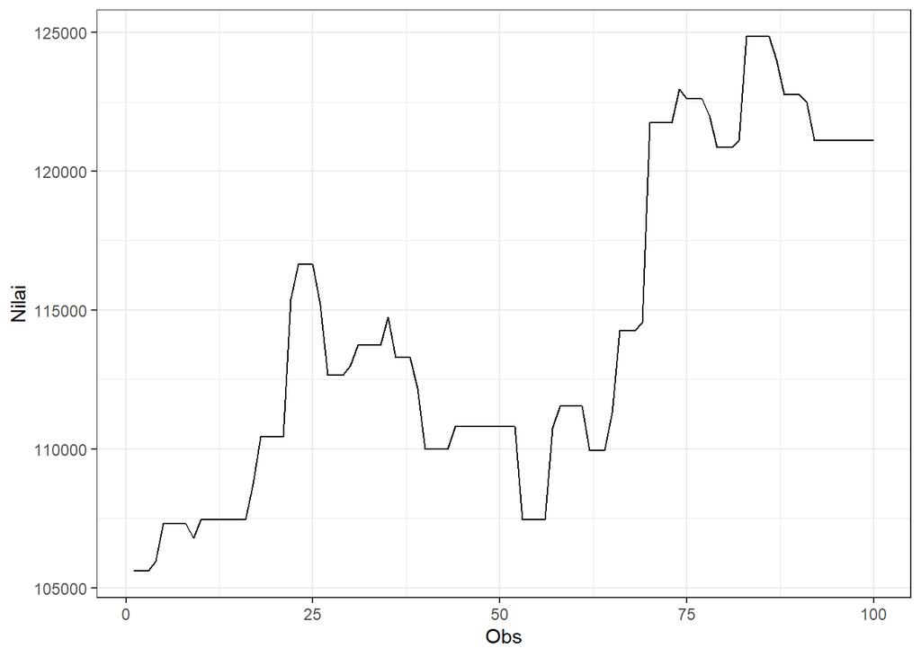

```r
datam5.ts2|> as_tsibble() |>
  ggplot(aes(x = index, y = value)) +
  geom_line() + theme_bw() +
  xlab("Obs") + ylab("Nilai")
```

Berdasarkan plot time series tersebut, terlihat bahwa data tidak stasioner dalam rataan karena masih terdapat tren pada data, dan tidak stasioner dalam ragam karena memiliki lebar pita yang cenderung tidak sama

#### Plot ACF

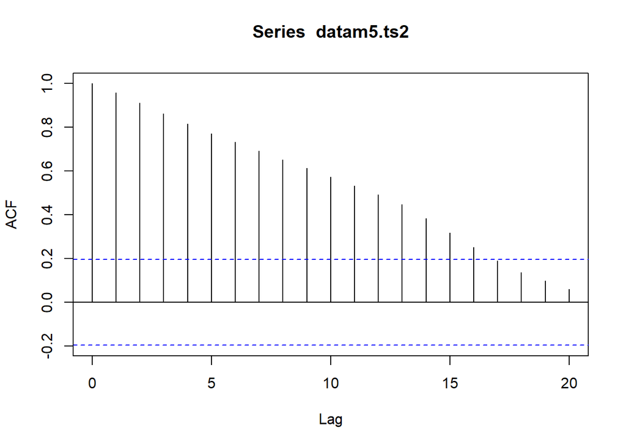

```r
acf(datam5.ts2)
```

Berdasarkan plot ACF, terlihat bahwa plot ACF pada data tersebut menurun secara perlahan (*tails off slowly*) yang menandakan data tidak stasioner dalam rataan

#### Uji ADF

```r
adf.test(datam5.ts2)
```

```
##
##  Augmented Dickey-Fuller Test
##
## data:  datam5.ts2
## Dickey-Fuller = -2.1114, Lag order = 4, p-value = 0.5305
## alternative hypothesis: stationary
```

$H_0$ : Data tidak stasioner dalam rataan

$H_1$ : Data stasioner dalam rataan

Berdasarkan uji ADF tersebut, didapat *p-value* sebesar 0.5305 yang lebih besar dari taraf nyata 5% dan menandakan bahwa data tidak stasioner dalam rataan. Hal ini sesuai dengan hasil eksplorasi menggunakan plot time series dan plot ACF

####Plot Box-Cox

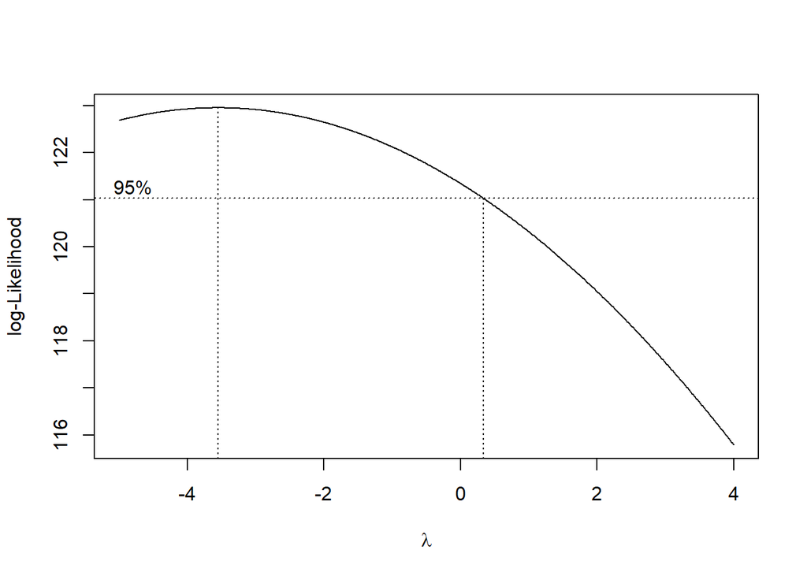

```r
index <- seq(1:100)
bc = boxcox(datam5.ts2~index, lambda = seq(-5,4,by=0.01))
```

```r
#Nilai Rounded Lambda
lambda <- bc$x[which.max(bc$y)]
lambda
```

```
## [1] -3.55
```

```r
#SK
bc$x[bc$y > max(bc$y) - 1/2 * qchisq(.95,1)]
```

```
##   [1] -5.00 -4.99 -4.98 -4.97 -4.96 -4.95 -4.94 -4.93 -4.92 -4.91 -4.90 -4.89
##  [13] -4.88 -4.87 -4.86 -4.85 -4.84 -4.83 -4.82 -4.81 -4.80 -4.79 -4.78 -4.77
##  [25] -4.76 -4.75 -4.74 -4.73 -4.72 -4.71 -4.70 -4.69 -4.68 -4.67 -4.66 -4.65
##  [37] -4.64 -4.63 -4.62 -4.61 -4.60 -4.59 -4.58 -4.57 -4.56 -4.55 -4.54 -4.53
##  [49] -4.52 -4.51 -4.50 -4.49 -4.48 -4.47 -4.46 -4.45 -4.44 -4.43 -4.42 -4.41
##  [61] -4.40 -4.39 -4.38 -4.37 -4.36 -4.35 -4.34 -4.33 -4.32 -4.31 -4.30 -4.29
##  [73] -4.28 -4.27 -4.26 -4.25 -4.24 -4.23 -4.22 -4.21 -4.20 -4.19 -4.18 -4.17
##  [85] -4.16 -4.15 -4.14 -4.13 -4.12 -4.11 -4.10 -4.09 -4.08 -4.07 -4.06 -4.05
##  [97] -4.04 -4.03 -4.02 -4.01 -4.00 -3.99 -3.98 -3.97 -3.96 -3.95 -3.94 -3.93
## [109] -3.92 -3.91 -3.90 -3.89 -3.88 -3.87 -3.86 -3.85 -3.84 -3.83 -3.82 -3.81
## [121] -3.80 -3.79 -3.78 -3.77 -3.76 -3.75 -3.74 -3.73 -3.72 -3.71 -3.70 -3.69
## [133] -3.68 -3.67 -3.66 -3.65 -3.64 -3.63 -3.62 -3.61 -3.60 -3.59 -3.58 -3.57
## [145] -3.56 -3.55 -3.54 -3.53 -3.52 -3.51 -3.50 -3.49 -3.48 -3.47 -3.46 -3.45
## [157] -3.44 -3.43 -3.42 -3.41 -3.40 -3.39 -3.38 -3.37 -3.36 -3.35 -3.34 -3.33
## [169] -3.32 -3.31 -3.30 -3.29 -3.28 -3.27 -3.26 -3.25 -3.24 -3.23 -3.22 -3.21
```

[output cut: 30 more lines]

Gambar di atas menunjukkan nilai *rounded value* ($\lambda$) optimum sebesar **-3.55** dan pada selang kepercayaan 95% nilai memiliki batas atas **0.33**. Selang tersebut tidak memuat nilai satu sehingga dapat dikatakan bahwa data bagian 2 tidak stasioner dalam ragam.